# TimeSeries-GitHub

## Kat

#### BUAD 5112, M3: Time Series Decomposition Assignment

#### September 19, 2021

```python
# Load packages needed
%matplotlib inline
import pandas as pd
import numpy as np
import matplotlib.pyplot as plt
from scipy import stats
```

## Analyzing Private Construction with Time Series Decomposition

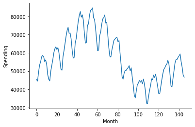

```python
# Private Construction: Load and visualize the data
dfCS = pd.read_csv('ConstructionTimeSeriesDataV2.csv')

fig, ax = plt.subplots()
ax.plot(dfCS['Private Construction'], label = 'Private Construction Sales')
ax.set_xlabel('Month')
ax.set_ylabel('Spending')
ax.spines['right'].set_visible(False)
ax.spines['top'].set_visible(False)
```

A quick look at the data shows us it is non-linear. There are "component patterns", which looks like waves which indicates seasonality. We would want to research what is causing those patterns in the data. If we decompose the data, we can forecase the future and how the components will repeat.

Next we compute the moving average of each point for a data window. The window size used here is 36, and the average squared error is computed in order to help evaluate which window size is appropriate for the moving average.

```python
# Private Construction: Compute moving average
def sqErr(row):
    return (row['Private Construction'] - row['MovAvg'])**2

dfCS['MovAvg'] = np.NaN
dfCS['sqErr'] = np.NaN
# Changing the DataFrame index to DatetimeIndex data type is required for using one of the functions below
dfCS.index = pd.date_range(freq = 'm', start = pd.Timestamp(year = 2002, month = 1, day = 2), periods = len(dfCS['Private Construction']))
print(len(dfCS),'\n',dfCS)

window = 36
window = window - window % 2
# Compute the moving average in the loop below using a window centered on the data point whose average is being computed
for i in range(int(window/2),dfCS.shape[0]-int(window/2)):
    dfCS.loc[dfCS.index[i],'MovAvg'] = (0.5*dfCS.iloc[i - int(window/2)]['Private Construction'] + dfCS.iloc[i - int(window/2)+1:i + int(window/2)]['Private Construction'].sum() + 0.5*dfCS.iloc[i + int(window/2)]['Private Construction'])/float(window)

dfCS['sqErr'] = (dfCS['Private Construction'] - dfCS['MovAvg'])**2

# The moving average cannot be applied to all rows and we need to delete those rows because we cannot use them in the analysis
dfCS.dropna(how='any',inplace=True)

print('Average Squared Error per Month: ', sum(dfCS['sqErr'])/len(dfCS))
print(dfCS)
```

```
146
             Month Month-Year  Total Construction  Private Construction  \
2002-01-31      1      2-Jan               59516                 45273
2002-02-28      2      2-Feb               58588                 44475
2002-03-31      3      2-Mar               63782                 49396
2002-04-30      4      2-Apr               69504                 53283
2002-05-31      5      2-May               73384                 55009
...           ...        ...                 ...                   ...
2013-10-31    142     13-Oct               85193                 59370
2013-11-30    143     13-Nov               77931                 55191
2013-12-31    144     13-Dec               71502                 52132
2014-01-31    145     14-Jan               64661                 47827
2014-02-28    146     14-Feb               63368                 46647

            Public Construction  MovAvg  sqErr
2002-01-31                14243     NaN    NaN
2002-02-28                14113     NaN    NaN
2002-03-31                14386     NaN    NaN
2002-04-30                16221     NaN    NaN
2002-05-31                18375     NaN    NaN
...                         ...     ...    ...
2013-10-31                25823     NaN    NaN
2013-11-30                22741     NaN    NaN
2013-12-31                19369     NaN    NaN
2014-01-31                16834     NaN    NaN
2014-02-28                16721     NaN    NaN

[146 rows x 7 columns]
Average Squared Error per Month:  37395667.05489795
            Month Month-Year  Total Construction  Private Construction  \
2003-07-31     19      3-Jul               82971                 62216
2003-08-31     20      3-Aug               85191                 63234
2003-09-30     21      3-Sep               83841                 61767
2003-10-31     22      3-Oct               83133                 62813
2003-11-30     23      3-Nov               77915                 60115
...           ...        ...                 ...                   ...
2012-04-30    124     12-Apr               66223                 44964
2012-05-31    125     12-May               72240                 48342
2012-06-30    126     12-Jun               77876                 50900
2012-07-31    127     12-Jul               78897                 51794
2012-08-31    128     12-Aug               81712                 53073

            Public Construction        MovAvg         sqErr
2003-07-31                20755  57969.430556  1.803335e+07
2003-08-31                21957  58314.944444  2.419711e+07
2003-09-30                22075  58718.902778  9.290897e+06
2003-10-31                20321  59143.555556  1.346482e+07
2003-11-30                17801  59593.541667  2.719188e+05
...                         ...           ...           ...
2012-04-30                21259  46543.069444  2.493460e+06
2012-05-31                23898  46907.194444  2.058667e+06
2012-06-30                26975  47262.611111  1.323060e+07
2012-07-31                27104  47660.583333  1.708513e+07
2012-08-31                28640  48077.638889  2.495363e+07

[110 rows x 7 columns]
```

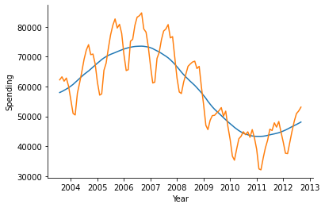

```python
# Plot moving average
fig,ax = plt.subplots()
ax.plot(dfCS['MovAvg'],label='Moving Avg.')
ax.plot(dfCS['Private Construction'],label='Private Construction Sales')
ax.set_xlabel('Year')
ax.set_ylabel('Spending')
ax.spines['right'].set_visible(False)
ax.spines['top'].set_visible(False)
```

Next we calculate the residual sales (R1) using the moving average subtracted from the demand.

```python
# Private Construction: Compute Residual and Error
dfCS['R1'] = dfCS['Private Construction'] - dfCS['MovAvg']
dfCS['R1Error'] = abs((dfCS['Private Construction'] - dfCS['R1'])/dfCS['Private Construction'])
dfCS.style.format({
    'MovAvg': '{:.1f}'.format,
    'sqErr': '{:,.1f}'.format,
    'R1': '{:,.1f}'.format,
    'R1Error': '{:,.3f}'.format
})
```

|  | Month | Month-Year | Total Construction | Private Construction | Public Construction | MovAvg | sqErr | R1 | R1Error |
| --- | --- | --- | --- | --- | --- | --- | --- | --- | --- |
| 2003-07-31 00:00:00 | 19 | 3-Jul | 82971 | 62216 | 20755 | 57969.4 | 18,033,352.0 | 4,246.6 | 0.932 |
| 2003-08-31 00:00:00 | 20 | 3-Aug | 85191 | 63234 | 21957 | 58314.9 | 24,197,107.6 | 4,919.1 | 0.922 |
| 2003-09-30 00:00:00 | 21 | 3-Sep | 83841 | 61767 | 22075 | 58718.9 | 9,290,896.7 | 3,048.1 | 0.951 |
| 2003-10-31 00:00:00 | 22 | 3-Oct | 83133 | 62813 | 20321 | 59143.6 | 13,464,822.5 | 3,669.4 | 0.942 |
| 2003-11-30 00:00:00 | 23 | 3-Nov | 77915 | 60115 | 17801 | 59593.5 | 271,918.8 | 521.5 | 0.991 |
| 2003-12-31 00:00:00 | 24 | 3-Dec | 71050 | 55584 | 15466 | 60111.7 | 20,500,394.3 | -4,527.7 | 1.081 |
| 2004-01-31 00:00:00 | 25 | 4-Jan | 64934 | 50975 | 13959 | 60687.3 | 94,329,418.8 | -9,712.3 | 1.191 |
| 2004-02-29 00:00:00 | 26 | 4-Feb | 64138 | 50449 | 13689 | 61335.4 | 118,514,067.8 | -10,886.4 | 1.216 |
| 2004-03-31 00:00:00 | 27 | 4-Mar | 73238 | 57796 | 15443 | 62017.4 | 17,820,241.4 | -4,221.4 | 1.073 |
| 2004-04-30 00:00:00 | 28 | 4-Apr | 78354 | 61177 | 17177 | 62701.1 | 2,322,787.7 | -1,524.1 | 1.025 |
| 2004-05-31 00:00:00 | 29 | 4-May | 83736 | 65027 | 18709 | 63381.9 | 2,706,390.6 | 1,645.1 | 0.975 |
| 2004-06-30 00:00:00 | 30 | 4-Jun | 89932 | 69039 | 20893 | 64033.2 | 25,058,506.4 | 5,005.8 | 0.927 |
| 2004-07-31 00:00:00 | 31 | 4-Jul | 93614 | 72170 | 21444 | 64623.9 | 56,943,373.7 | 7,546.1 | 0.895 |
| 2004-08-31 00:00:00 | 32 | 4-Aug | 96164 | 74001 | 22164 | 65191.5 | 77,606,800.8 | 8,809.5 | 0.881 |
| 2004-09-30 00:00:00 | 33 | 4-Sep | 92538 | 70662 | 21876 | 65832.8 | 23,321,521.4 | 4,829.2 | 0.932 |
| 2004-10-31 00:00:00 | 34 | 4-Oct | 90582 | 70856 | 19726 | 66496.0 | 19,009,721.1 | 4,360.0 | 0.938 |
| 2004-11-30 00:00:00 | 35 | 4-Nov | 86394 | 67585 | 18809 | 67145.8 | 192,891.8 | 439.2 | 0.994 |
| 2004-12-31 00:00:00 | 36 | 4-Dec | 77733 | 61438 | 16295 | 67803.1 | 40,513,932.2 | -6,365.1 | 1.104 |
| 2005-01-31 00:00:00 | 37 | 5-Jan | 71474 | 57094 | 14380 | 68422.6 | 128,336,171.0 | -11,328.6 | 1.198 |
| 2005-02-28 00:00:00 | 38 | 5-Feb | 72048 | 57531 | 14517 | 69018.4 | 131,959,784.4 | -11,487.4 | 1.200 |
| 2005-03-31 00:00:00 | 39 | 5-Mar | 81345 | 65425 | 15920 | 69558.9 | 17,088,922.5 | -4,133.9 | 1.063 |
| 2005-04-30 00:00:00 | 40 | 5-Apr | 85485 | 67829 | 17656 | 70015.6 | 4,781,389.6 | -2,186.6 | 1.032 |
| 2005-05-31 00:00:00 | 41 | 5-May | 92959 | 72862 | 20097 | 70414.7 | 5,989,304.5 | 2,447.3 | 0.966 |
| 2005-06-30 00:00:00 | 42 | 5-Jun | 99632 | 77258 | 22375 | 70758.2 | 42,247,111.2 | 6,499.8 | 0.916 |
| 2005-07-31 00:00:00 | 43 | 5-Jul | 103158 | 80480 | 22679 | 71057.9 | 88,776,701.2 | 9,422.1 | 0.883 |
| 2005-08-31 00:00:00 | 44 | 5-Aug | 106706 | 82629 | 24078 | 71351.9 | 127,171,982.0 | 11,277.1 | 0.864 |
| 2005-09-30 00:00:00 | 45 | 5-Sep | 103269 | 79584 | 23685 | 71665.8 | 62,698,463.1 | 7,918.2 | 0.901 |
| 2005-10-31 00:00:00 | 46 | 5-Oct | 102339 | 80820 | 21519 | 71969.4 | 78,332,825.3 | 8,850.6 | 0.890 |
| 2005-11-30 00:00:00 | 47 | 5-Nov | 97549 | 77774 | 19775 | 72259.9 | 30,405,421.3 | 5,514.1 | 0.929 |
| 2005-12-31 00:00:00 | 48 | 5-Dec | 88172 | 70692 | 17479 | 72540.2 | 3,415,771.4 | -1,848.2 | 1.026 |

[output cut: 80 more lines]

```
Average Residual:  113.25315656565621
```

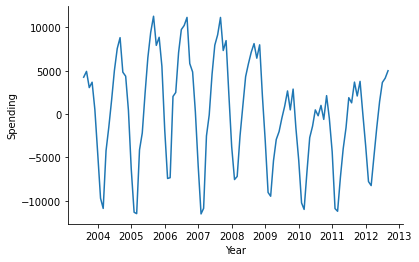

```python
# Private Construction: Plot Average Residual and Display Average Residual
fig,ax = plt.subplots()
ax.plot(dfCS['R1'])
ax.set_xlabel('Year')
ax.set_ylabel('Spending')
ax.spines['right'].set_visible(False)
ax.spines['top'].set_visible(False)
print('Average Residual: ', sum(dfCS['R1'])/len(dfCS))
```

```python
# Calculate Autocorrelation to detect any cyclical patterns and how many periods before they repeat
maxCorr = 0.0
period = np.NaN
for i in range(1,147):
    corr = dfCS['R1'].autocorr(lag=i)
    print('Correlation, lag ',i,'   ',corr)
    if corr > maxCorr:
        maxCorr = corr
        period = i
print('period = ',period,'     Maximum Correlation = ',maxCorr)
```

```
Correlation, lag  1     0.8250475036301713
Correlation, lag  2     0.4820939752221447
Correlation, lag  3     0.0661838628463355
Correlation, lag  4     -0.29310582259154694
Correlation, lag  5     -0.5386625150984725
Correlation, lag  6     -0.6496282831082484
Correlation, lag  7     -0.549838477475518
Correlation, lag  8     -0.3185413831731613
Correlation, lag  9     0.02011606382325631
Correlation, lag  10     0.41176952584284515
Correlation, lag  11     0.7322731003955263
Correlation, lag  12     0.8944851710984221
Correlation, lag  13     0.7299213692607464
Correlation, lag  14     0.4055214152186815
Correlation, lag  15     0.0031237974667481893
Correlation, lag  16     -0.34159925855108353
Correlation, lag  17     -0.5745510163732713
Correlation, lag  18     -0.681216824190257
Correlation, lag  19     -0.5902172854543253
Correlation, lag  20     -0.37531995989940625
Correlation, lag  21     -0.04750388422754723
Correlation, lag  22     0.3369494305895757
Correlation, lag  23     0.6572135458224128
Correlation, lag  24     0.8250377247910974
Correlation, lag  25     0.6796473144842703
Correlation, lag  26     0.3697716757524485
Correlation, lag  27     -0.031763738440921285
Correlation, lag  28     -0.3864486695652997
Correlation, lag  29     -0.629267851757631
Correlation, lag  30     -0.7352864412725051
Correlation, lag  31     -0.6386019116542909
Correlation, lag  32     -0.42297520217029344
Correlation, lag  33     -0.09831675443648784
Correlation, lag  34     0.281952534008814
Correlation, lag  35     0.6041349156276149
Correlation, lag  36     0.786554093702412
Correlation, lag  37     0.6641391870781225
Correlation, lag  38     0.3594087503532769
Correlation, lag  39     -0.0461214129836942
Correlation, lag  40     -0.4091309157082801
```

[output cut: 92 more lines]

```
Correlation, lag  133     nan
Correlation, lag  134     nan
Correlation, lag  135     nan
Correlation, lag  136     nan
Correlation, lag  137     nan
Correlation, lag  138     nan
Correlation, lag  139     nan
Correlation, lag  140     nan
Correlation, lag  141     nan
Correlation, lag  142     nan
Correlation, lag  143     nan
Correlation, lag  144     nan
Correlation, lag  145     nan
Correlation, lag  146     nan
period =  108      Maximum Correlation =  0.9999999999999999
```

We now calculate autocorrelation to detect any cyclical patterns how many periods before they are repeated.

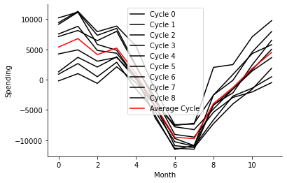

```python
# Break the time series up, computes average of period, and plots the patterns and averages
period = 12
cycleLen = period
numCycles = int(len(dfCS)/cycleLen + 0.5)
cycles = [dfCS.iloc[range(i*period,min((i+1)*period,len(dfCS)))]['R1'] for i in range(numCycles)]
ptsInCycles = [dfCS.iloc[range(i,len(dfCS['R1']),period)]['R1'].tolist() for i in range(period)]
avg = [sum(pts)/len(pts) for pts in ptsInCycles]

fig,ax = plt.subplots()
for i in range(len(cycles)):
    ax.plot(cycles[i].values,label='Cycle '+str(i),c='k')
ax.plot(avg,label='Average Cycle',c='r')
ax.set_xlabel('Month')
ax.set_ylabel('Spending')
ax.spines['right'].set_visible(False)
ax.spines['top'].set_visible(False)
ax.legend()
```

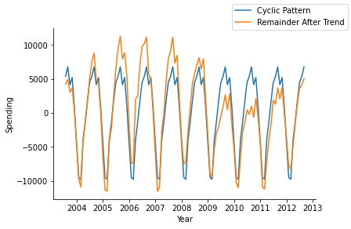

```python
# Inserts the appropriate C(m) value into the C column for month, then plots the cyclicity component

cycleLen = period   # see prior cell for computation of cyclicality period
numCycles = int(len(dfCS)/cycleLen + 0.5)
dfCS['C'] = np.NaN   # Creates an empty column for the cyclicality component data
for i in range(len(dfCS)):
    dfCS.loc[dfCS.index[i], 'C'] = avg[i % cycleLen] # Write appropriate cyclicality value

fig,ax = plt.subplots()
ax.plot(dfCS['C'],label='Cyclic Pattern')
ax.plot(dfCS['R1'],label='Remainder After Trend')
ax.set_xlabel('Year')
ax.set_ylabel('Spending')
ax.spines['right'].set_visible(False)
ax.spines['top'].set_visible(False)
fig.legend()
```

```
Average Error:  0.037815969902102356
            Month Month-Year  Total Construction  Private Construction  \
2003-07-31     19      3-Jul               82971                 62216
2003-08-31     20      3-Aug               85191                 63234
2003-09-30     21      3-Sep               83841                 61767
2003-10-31     22      3-Oct               83133                 62813
2003-11-30     23      3-Nov               77915                 60115
...           ...        ...                 ...                   ...
2012-04-30    124     12-Apr               66223                 44964
2012-05-31    125     12-May               72240                 48342
2012-06-30    126     12-Jun               77876                 50900
2012-07-31    127     12-Jul               78897                 51794
2012-08-31    128     12-Aug               81712                 53073

            Public Construction        MovAvg           R1   R1Error  \
2003-07-31                20755  57969.430556  4246.569444  0.931745
2003-08-31                21957  58314.944444  4919.055556  0.922209
2003-09-30                22075  58718.902778  3048.097222  0.950652
2003-10-31                20321  59143.555556  3669.444444  0.941581
2003-11-30                17801  59593.541667   521.458333  0.991326
...                         ...           ...          ...       ...
2012-04-30                21259  46543.069444 -1579.069444  1.035119
2012-05-31                23898  46907.194444  1434.805556  0.970320
2012-06-30                26975  47262.611111  3637.388889  0.928539
2012-07-31                27104  47660.583333  4133.416667  0.920195
2012-08-31                28640  48077.638889  4995.361111  0.905878

                      C    R2Private  R2ErrorPrivate           fit
2003-07-31  5381.098611 -1134.529167        0.018235  63350.529167
2003-08-31  6774.126389 -1855.070833        0.029337  65089.070833
2003-09-30  4146.766975 -1098.669753        0.017787  62865.669753
2003-10-31  5216.117284 -1546.672840        0.024623  64359.672840
2003-11-30  1011.337963  -489.879630        0.008149  60604.879630
...                 ...          ...             ...           ...
2012-04-30 -1303.533951  -275.535494        0.006128  45239.535494
2012-05-31  1834.348765  -399.543210        0.008265  48741.543210
2012-06-30  4496.526235  -859.137346        0.016879  51759.137346
2012-07-31  5381.098611 -1247.681944        0.024089  53041.681944
2012-08-31  6774.126389 -1778.765278        0.033515  54851.765278

[110 rows x 12 columns]
```

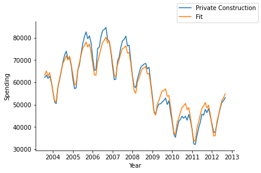

```python
# Computes remaining residual sales, computes the error, computes the 'fit', plots the model, computes the avg absolute error, and remove the sqErr column
dfCS['R2Private'] = dfCS['R1'] - dfCS['C']
dfCS['R2ErrorPrivate'] = abs(dfCS['R2Private']/dfCS['Private Construction'])
dfCS['fit'] = dfCS['MovAvg'] + dfCS['C']
dfCS.drop(['sqErr'],axis=1,inplace=True)
print('Average Error: ', sum(dfCS['R2ErrorPrivate'])/len(dfCS))
print(dfCS)
fig,ax = plt.subplots()
ax.plot(dfCS['Private Construction'],label='Private Construction')
ax.plot(dfCS['fit'], label = 'Fit')
ax.set_xlabel('Year')
ax.set_ylabel('Spending')
ax.spines['right'].set_visible(False)
ax.spines['top'].set_visible(False)
fig.legend()
```

```
Correlation, lag  1     0.9027847832948318
Correlation, lag  2     0.7955702460094589
Correlation, lag  3     0.6560564735350041
Correlation, lag  4     0.5316739965331645
Correlation, lag  5     0.40216413631183895
Correlation, lag  6     0.3295267465640479
Correlation, lag  7     0.30585196484336047
Correlation, lag  8     0.330740986282625
Correlation, lag  9     0.3513528536369925
Correlation, lag  10     0.39197130708064265
Correlation, lag  11     0.42152079795616615
Correlation, lag  12     0.45317295658989853
Correlation, lag  13     0.39968224552326453
Correlation, lag  14     0.35553340791809884
Correlation, lag  15     0.2609189789415448
Correlation, lag  16     0.19032184469495012
Correlation, lag  17     0.12087743508505222
Correlation, lag  18     0.09559969424180809
Correlation, lag  19     0.09972184559354913
Correlation, lag  20     0.11683883938478473
Correlation, lag  21     0.12449790662917444
Correlation, lag  22     0.1325196757849622
Correlation, lag  23     0.13449624932122822
Correlation, lag  24     0.11560577480136838
Correlation, lag  25     0.07426674036471838
Correlation, lag  26     0.049966516641019
Correlation, lag  27     -0.010015257069288333
Correlation, lag  28     -0.040724392215721855
Correlation, lag  29     -0.07540253846044244
Correlation, lag  30     -0.09347573174642604
Correlation, lag  31     -0.11658429414096219
Correlation, lag  32     -0.14765407471977637
Correlation, lag  33     -0.18384858126360112
Correlation, lag  34     -0.23800928329336715
Correlation, lag  35     -0.2737349318189361
Correlation, lag  36     -0.3319322921539422
period =  1      Maximum Correlation =  0.9027847832948318
```

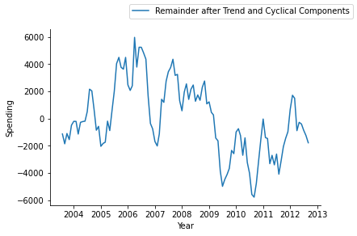

```python
fig,ax = plt.subplots()
ax.plot(dfCS['R2Private'],label='Remainder after Trend and Cyclical Components')
ax.set_xlabel('Year')
ax.set_ylabel('Spending')
ax.spines['right'].set_visible(False)
ax.spines['top'].set_visible(False)
fig.legend()
maxCorr = 0.0
period = np.NaN
for i in range(1,37):
    corr = dfCS['R2Private'].autocorr(lag=i)
    print('Correlation, lag ',i,'   ',corr)
    if corr > maxCorr:
        maxCorr = corr
        period = i
print('period = ',period,'     Maximum Correlation = ',maxCorr)
```

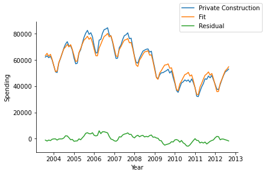

```python
fig,ax = plt.subplots()
ax.plot(dfCS['Private Construction'],label='Private Construction')
ax.plot(dfCS['fit'],label='Fit')
ax.plot(dfCS['R2Private'],label='Residual')
ax.set_xlabel('Year')
ax.set_ylabel('Spending')
ax.spines['right'].set_visible(False)
ax.spines['top'].set_visible(False)
fig.legend()
```

## Analyzing Public Construction with Time Series Decomposition

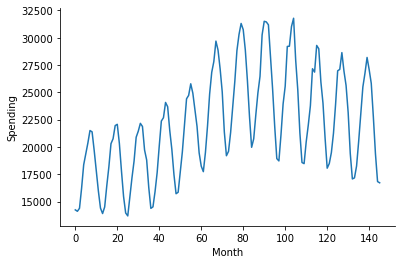

```python
# Public Construction: Load and visualize the data
dfCS = pd.read_csv('ConstructionTimeSeriesDataV2.csv')

fig, ax = plt.subplots()
ax.plot(dfCS['Public Construction'], label = 'Public Construction Sales')
ax.set_xlabel('Month')
ax.set_ylabel('Spending')
ax.spines['right'].set_visible(False)
ax.spines['top'].set_visible(False)
```

A quick look at the data shows us it is non-linear. There are "component patterns", which looks like waves which indicates seasonality. We would want to research what is causing those patterns in the data. If we decompose the data, we can forecase the future and how the components will repeat.

Next we compute the moving average of each point for a data window. The window size used here is 36, and the average squared error is computed in order to help evaluate which window size is appropriate for the moving average.

```python
# Public Construction: Compute moving average
def sqErr(row):
    return (row['Public Construction'] - row['MovAvg'])**2

dfCS['MovAvg'] = np.NaN
dfCS['sqErr'] = np.NaN
# Changing the DataFrame index to DatetimeIndex data type is required for using one of the functions below
dfCS.index = pd.date_range(freq = 'm', start = pd.Timestamp(year = 2002, month = 1, day = 2), periods = len(dfCS['Public Construction']))
print(len(dfCS),'\n',dfCS)

window = 36
window = window - window % 2
# Compute the moving average in the loop below using a window centered on the data point whose average is being computed
for i in range(int(window/2),dfCS.shape[0]-int(window/2)):
    dfCS.loc[dfCS.index[i],'MovAvg'] = (0.5*dfCS.iloc[i - int(window/2)]['Public Construction'] + dfCS.iloc[i - int(window/2)+1:i + int(window/2)]['Public Construction'].sum() + 0.5*dfCS.iloc[i + int(window/2)]['Public Construction'])/float(window)

dfCS['sqErr'] = (dfCS['Public Construction'] - dfCS['MovAvg'])**2

# The moving average cannot be applied to all rows and we need to delete those rows because we cannot use them in the analysis
dfCS.dropna(how='any',inplace=True)

print('Average Squared Error per Month: ', sum(dfCS['sqErr'])/len(dfCS))
print(dfCS)
```

```
146
             Month Month-Year  Total Construction  Private Construction  \
2002-01-31      1      2-Jan               59516                 45273
2002-02-28      2      2-Feb               58588                 44475
2002-03-31      3      2-Mar               63782                 49396
2002-04-30      4      2-Apr               69504                 53283
2002-05-31      5      2-May               73384                 55009
...           ...        ...                 ...                   ...
2013-10-31    142     13-Oct               85193                 59370
2013-11-30    143     13-Nov               77931                 55191
2013-12-31    144     13-Dec               71502                 52132
2014-01-31    145     14-Jan               64661                 47827
2014-02-28    146     14-Feb               63368                 46647

            Public Construction  MovAvg  sqErr
2002-01-31                14243     NaN    NaN
2002-02-28                14113     NaN    NaN
2002-03-31                14386     NaN    NaN
2002-04-30                16221     NaN    NaN
2002-05-31                18375     NaN    NaN
...                         ...     ...    ...
2013-10-31                25823     NaN    NaN
2013-11-30                22741     NaN    NaN
2013-12-31                19369     NaN    NaN
2014-01-31                16834     NaN    NaN
2014-02-28                16721     NaN    NaN

[146 rows x 7 columns]
Average Squared Error per Month:  13581548.10100133
            Month Month-Year  Total Construction  Private Construction  \
2003-07-31     19      3-Jul               82971                 62216
2003-08-31     20      3-Aug               85191                 63234
2003-09-30     21      3-Sep               83841                 61767
2003-10-31     22      3-Oct               83133                 62813
2003-11-30     23      3-Nov               77915                 60115
...           ...        ...                 ...                   ...
2012-04-30    124     12-Apr               66223                 44964
2012-05-31    125     12-May               72240                 48342
2012-06-30    126     12-Jun               77876                 50900
2012-07-31    127     12-Jul               78897                 51794
2012-08-31    128     12-Aug               81712                 53073

            Public Construction        MovAvg         sqErr
2003-07-31                20755  18050.486111  7.314395e+06
2003-08-31                21957  18058.000000  1.520220e+07
2003-09-30                22075  18084.916667  1.592077e+07
2003-10-31                20321  18126.152778  4.817354e+06
2003-11-30                17801  18170.000000  1.361610e+05
...                         ...           ...           ...
2012-04-30                21259  23397.138889  4.571638e+06
2012-05-31                23898  23333.500000  3.186602e+05
2012-06-30                26975  23272.680556  1.370717e+07
2012-07-31                27104  23222.000000  1.506992e+07
2012-08-31                28640  23173.416667  2.988353e+07

[110 rows x 7 columns]
```

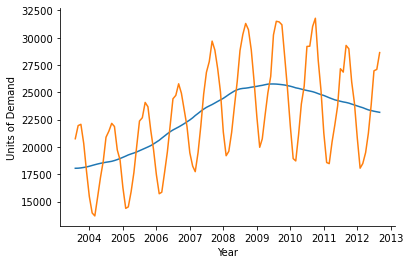

```python
# Public Construction: plot moving average
fig,ax = plt.subplots()
ax.plot(dfCS['MovAvg'],label='Moving Avg.')
ax.plot(dfCS['Public Construction'],label='Public Construction Sales')
ax.set_xlabel('Year')
ax.set_ylabel('Units of Demand')
ax.spines['right'].set_visible(False)
ax.spines['top'].set_visible(False)
```

Next we calculate the residual sales (R1) using the moving average subtracted from the demand.

```python
# Public Construction: Compute Residual and Error
dfCS['R1'] = dfCS['Public Construction'] - dfCS['MovAvg']
dfCS['R1Error'] = abs((dfCS['Public Construction'] - dfCS['R1'])/dfCS['Public Construction'])
dfCS.style.format({
    'MovAvg': '{:.1f}'.format,
    'sqErr': '{:,.1f}'.format,
    'R1': '{:,.1f}'.format,
    'R1Error': '{:,.3f}'.format
})
```

|  | Month | Month-Year | Total Construction | Private Construction | Public Construction | MovAvg | sqErr | R1 | R1Error |
| --- | --- | --- | --- | --- | --- | --- | --- | --- | --- |
| 2003-07-31 00:00:00 | 19 | 3-Jul | 82971 | 62216 | 20755 | 18050.5 | 7,314,395.4 | 2,704.5 | 0.870 |
| 2003-08-31 00:00:00 | 20 | 3-Aug | 85191 | 63234 | 21957 | 18058.0 | 15,202,201.0 | 3,899.0 | 0.822 |
| 2003-09-30 00:00:00 | 21 | 3-Sep | 83841 | 61767 | 22075 | 18084.9 | 15,920,765.0 | 3,990.1 | 0.819 |
| 2003-10-31 00:00:00 | 22 | 3-Oct | 83133 | 62813 | 20321 | 18126.2 | 4,817,354.3 | 2,194.8 | 0.892 |
| 2003-11-30 00:00:00 | 23 | 3-Nov | 77915 | 60115 | 17801 | 18170.0 | 136,161.0 | -369.0 | 1.021 |
| 2003-12-31 00:00:00 | 24 | 3-Dec | 71050 | 55584 | 15466 | 18235.5 | 7,670,130.2 | -2,769.5 | 1.179 |
| 2004-01-31 00:00:00 | 25 | 4-Jan | 64934 | 50975 | 13959 | 18309.2 | 18,923,950.0 | -4,350.2 | 1.312 |
| 2004-02-29 00:00:00 | 26 | 4-Feb | 64138 | 50449 | 13689 | 18377.0 | 21,976,953.3 | -4,688.0 | 1.342 |
| 2004-03-31 00:00:00 | 27 | 4-Mar | 73238 | 57796 | 15443 | 18444.6 | 9,009,669.3 | -3,001.6 | 1.194 |
| 2004-04-30 00:00:00 | 28 | 4-Apr | 78354 | 61177 | 17177 | 18502.0 | 1,755,625.0 | -1,325.0 | 1.077 |
| 2004-05-31 00:00:00 | 29 | 4-May | 83736 | 65027 | 18709 | 18554.7 | 23,797.3 | 154.3 | 0.992 |
| 2004-06-30 00:00:00 | 30 | 4-Jun | 89932 | 69039 | 20893 | 18603.1 | 5,243,591.1 | 2,289.9 | 0.890 |
| 2004-07-31 00:00:00 | 31 | 4-Jul | 93614 | 72170 | 21444 | 18642.5 | 7,848,635.7 | 2,801.5 | 0.869 |
| 2004-08-31 00:00:00 | 32 | 4-Aug | 96164 | 74001 | 22164 | 18687.8 | 12,083,831.3 | 3,476.2 | 0.843 |
| 2004-09-30 00:00:00 | 33 | 4-Sep | 92538 | 70662 | 21876 | 18759.1 | 9,714,996.3 | 3,116.9 | 0.858 |
| 2004-10-31 00:00:00 | 34 | 4-Oct | 90582 | 70856 | 19726 | 18846.4 | 773,764.6 | 879.6 | 0.955 |
| 2004-11-30 00:00:00 | 35 | 4-Nov | 86394 | 67585 | 18809 | 18942.5 | 17,814.8 | -133.5 | 1.007 |
| 2004-12-31 00:00:00 | 36 | 4-Dec | 77733 | 61438 | 16295 | 19052.6 | 7,604,419.0 | -2,757.6 | 1.169 |
| 2005-01-31 00:00:00 | 37 | 5-Jan | 71474 | 57094 | 14380 | 19164.8 | 22,894,364.2 | -4,784.8 | 1.333 |
| 2005-02-28 00:00:00 | 38 | 5-Feb | 72048 | 57531 | 14517 | 19273.1 | 22,620,328.7 | -4,756.1 | 1.328 |
| 2005-03-31 00:00:00 | 39 | 5-Mar | 81345 | 65425 | 15920 | 19365.8 | 11,873,575.9 | -3,445.8 | 1.216 |
| 2005-04-30 00:00:00 | 40 | 5-Apr | 85485 | 67829 | 17656 | 19447.9 | 3,210,915.6 | -1,791.9 | 1.101 |
| 2005-05-31 00:00:00 | 41 | 5-May | 92959 | 72862 | 20097 | 19547.1 | 302,423.6 | 549.9 | 0.973 |
| 2005-06-30 00:00:00 | 42 | 5-Jun | 99632 | 77258 | 22375 | 19659.2 | 7,375,448.9 | 2,715.8 | 0.879 |
| 2005-07-31 00:00:00 | 43 | 5-Jul | 103158 | 80480 | 22679 | 19774.3 | 8,437,411.2 | 2,904.7 | 0.872 |
| 2005-08-31 00:00:00 | 44 | 5-Aug | 106706 | 82629 | 24078 | 19890.1 | 17,538,762.3 | 4,187.9 | 0.826 |
| 2005-09-30 00:00:00 | 45 | 5-Sep | 103269 | 79584 | 23685 | 20002.7 | 13,559,169.6 | 3,682.3 | 0.845 |
| 2005-10-31 00:00:00 | 46 | 5-Oct | 102339 | 80820 | 21519 | 20125.3 | 1,942,422.9 | 1,393.7 | 0.935 |
| 2005-11-30 00:00:00 | 47 | 5-Nov | 97549 | 77774 | 19775 | 20276.8 | 251,753.1 | -501.8 | 1.025 |
| 2005-12-31 00:00:00 | 48 | 5-Dec | 88172 | 70692 | 17479 | 20444.6 | 8,794,684.5 | -2,965.6 | 1.170 |

[output cut: 80 more lines]

```
Average Residual:  120.58522727272724
```

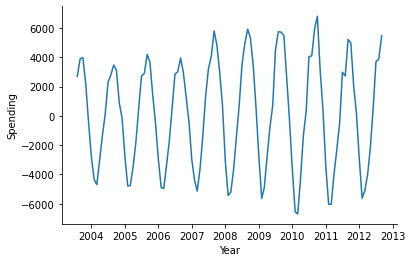

```python
# Public Construction: Plot Average Residual and Display Average Residual
fig,ax = plt.subplots()
ax.plot(dfCS['R1'])
ax.set_xlabel('Year')
ax.set_ylabel('Spending')
ax.spines['right'].set_visible(False)
ax.spines['top'].set_visible(False)
print('Average Residual: ', sum(dfCS['R1'])/len(dfCS))
```

```python
# Calculate Autocorrelation to detect any cyclical patterns and how many periods before they repeat
maxCorr = 0.0
period = np.NaN
for i in range(1,147):
    corr = dfCS['R1'].autocorr(lag=i)
    print('Correlation, lag ',i,'   ',corr)
    if corr > maxCorr:
        maxCorr = corr
        period = i
print('period = ',period,'     Maximum Correlation = ',maxCorr)
```

```
Correlation, lag  1     0.8486375316894602
Correlation, lag  2     0.4846195337567183
Correlation, lag  3     -0.007177248780703143
Correlation, lag  4     -0.49554892375973447
Correlation, lag  5     -0.8288179569669593
Correlation, lag  6     -0.9462777407123573
Correlation, lag  7     -0.8288579638039721
Correlation, lag  8     -0.48571061970010343
Correlation, lag  9     0.004997098591155971
Correlation, lag  10     0.4817646196968951
Correlation, lag  11     0.8389178942275625
Correlation, lag  12     0.9802446550357118
Correlation, lag  13     0.8361843883266434
Correlation, lag  14     0.4848265284305894
Correlation, lag  15     -0.003592213269114516
Correlation, lag  16     -0.48222336701850393
Correlation, lag  17     -0.8171150144686051
Correlation, lag  18     -0.9427534781166457
Correlation, lag  19     -0.8337051906400711
Correlation, lag  20     -0.4961430024835644
Correlation, lag  21     -0.009858447978117565
Correlation, lag  22     0.4684416329134112
Correlation, lag  23     0.8266661876059614
Correlation, lag  24     0.9712553048735744
Correlation, lag  25     0.8438762290583999
Correlation, lag  26     0.4966059057862167
Correlation, lag  27     0.00363557405229584
Correlation, lag  28     -0.47760887383472916
Correlation, lag  29     -0.8193773652675437
Correlation, lag  30     -0.9507330427079982
Correlation, lag  31     -0.8506201153800946
Correlation, lag  32     -0.5192149782007527
Correlation, lag  33     -0.03281414568805165
Correlation, lag  34     0.4561413678718069
Correlation, lag  35     0.8151545937149086
Correlation, lag  36     0.9633718688320395
Correlation, lag  37     0.8446768155560225
Correlation, lag  38     0.4954466635353492
Correlation, lag  39     0.00745645705728723
Correlation, lag  40     -0.4733389864162371
```

[output cut: 92 more lines]

```
Correlation, lag  133     nan
Correlation, lag  134     nan
Correlation, lag  135     nan
Correlation, lag  136     nan
Correlation, lag  137     nan
Correlation, lag  138     nan
Correlation, lag  139     nan
Correlation, lag  140     nan
Correlation, lag  141     nan
Correlation, lag  142     nan
Correlation, lag  143     nan
Correlation, lag  144     nan
Correlation, lag  145     nan
Correlation, lag  146     nan
period =  108      Maximum Correlation =  1.0
```

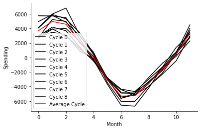

```python
# Break the time series up, computes average of period, and plots the patterns and averages
period = 12
cycleLen = period
numCycles = int(len(dfCS)/cycleLen + 0.5)
cycles = [dfCS.iloc[range(i*period,min((i+1)*period,len(dfCS)))]['R1'] for i in range(numCycles)]
ptsInCycles = [dfCS.iloc[range(i,len(dfCS['R1']),period)]['R1'].tolist() for i in range(period)]
avg = [sum(pts)/len(pts) for pts in ptsInCycles]

fig,ax = plt.subplots()
for i in range(len(cycles)):
    ax.plot(cycles[i].values,label='Cycle '+str(i),c='k')
ax.plot(avg,label='Average Cycle',c='r')
ax.set_xlabel('Month')
ax.set_ylabel('Spending')
ax.spines['right'].set_visible(False)
ax.spines['top'].set_visible(False)
ax.legend()
```

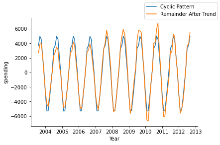

```python
# Inserts the appropriate C(m) value into the C column for month, then plots the cyclicity component

cycleLen = period   # see prior cell for computation of cyclicality period
numCycles = int(len(dfCS)/cycleLen + 0.5)
dfCS['C'] = np.NaN   # Creates an empty column for the cyclicality component data
for i in range(len(dfCS)):
    dfCS.loc[dfCS.index[i], 'C'] = avg[i % cycleLen] # Write appropriate cyclicality value

fig,ax = plt.subplots()
ax.plot(dfCS['C'],label='Cyclic Pattern')
ax.plot(dfCS['R1'],label='Remainder After Trend')
ax.set_xlabel('Year')
ax.set_ylabel('spending')
ax.spines['right'].set_visible(False)
ax.spines['top'].set_visible(False)
fig.legend()
```

```
Average Error:  0.024999478035219624
            Month Month-Year  Total Construction  Private Construction  \
2003-07-31     19      3-Jul               82971                 62216
2003-08-31     20      3-Aug               85191                 63234
2003-09-30     21      3-Sep               83841                 61767
2003-10-31     22      3-Oct               83133                 62813
2003-11-30     23      3-Nov               77915                 60115
...           ...        ...                 ...                   ...
2012-04-30    124     12-Apr               66223                 44964
2012-05-31    125     12-May               72240                 48342
2012-06-30    126     12-Jun               77876                 50900
2012-07-31    127     12-Jul               78897                 51794
2012-08-31    128     12-Aug               81712                 53073

            Public Construction        MovAvg           R1   R1Error  \
2003-07-31                20755  18050.486111  2704.513889  0.869693
2003-08-31                21957  18058.000000  3899.000000  0.822426
2003-09-30                22075  18084.916667  3990.083333  0.819249
2003-10-31                20321  18126.152778  2194.847222  0.891991
2003-11-30                17801  18170.000000  -369.000000  1.020729
...                         ...           ...          ...       ...
2012-04-30                21259  23397.138889 -2138.138889  1.100576
2012-05-31                23898  23333.500000   564.500000  0.976379
2012-06-30                26975  23272.680556  3702.319444  0.862750
2012-07-31                27104  23222.000000  3882.000000  0.856774
2012-08-31                28640  23173.416667  5466.583333  0.809128

                      C     R2Public  R2ErrorPublic           fit
2003-07-31  3690.790278  -986.276389       0.047520  21741.276389
2003-08-31  4961.773611 -1062.773611       0.048402  23019.773611
2003-09-30  4573.222222  -583.138889       0.026416  22658.138889
2003-10-31  2192.078704     2.768519       0.000136  20318.231481
2003-11-30    16.300926  -385.300926       0.021645  18186.300926
...                 ...          ...            ...           ...
2012-04-30 -1572.459877  -565.679012       0.026609  21824.679012
2012-05-31   510.810185    53.689815       0.002247  23844.310185
2012-06-30  3308.486111   393.833333       0.014600  26581.166667
2012-07-31  3690.790278   191.209722       0.007055  26912.790278
2012-08-31  4961.773611   504.809722       0.017626  28135.190278

[110 rows x 12 columns]
```

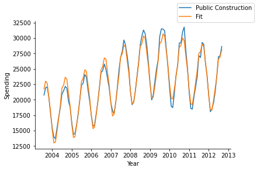

```python
# Computes remaining residual sales, computes the error, computes the 'fit', plots the model, computes the avg absolute error, and remove the sqErr column
dfCS['R2Public'] = dfCS['R1'] - dfCS['C']
dfCS['R2ErrorPublic'] = abs(dfCS['R2Public']/dfCS['Public Construction'])
dfCS['fit'] = dfCS['MovAvg'] + dfCS['C']
dfCS.drop(['sqErr'],axis=1,inplace=True)
print('Average Error: ', sum(dfCS['R2ErrorPublic'])/len(dfCS))
print(dfCS)
fig,ax = plt.subplots()
ax.plot(dfCS['Public Construction'],label='Public Construction')
ax.plot(dfCS['fit'], label = 'Fit')
ax.set_xlabel('Year')
ax.set_ylabel('Spending')
ax.spines['right'].set_visible(False)
ax.spines['top'].set_visible(False)
fig.legend()
```

```
Correlation, lag  1     0.7155376451059173
Correlation, lag  2     0.46852253106604014
Correlation, lag  3     0.25515329726845276
Correlation, lag  4     -0.04701265334308256
Correlation, lag  5     -0.22016658790924398
Correlation, lag  6     -0.3132037721816348
Correlation, lag  7     -0.36128568452449933
Correlation, lag  8     -0.24373155996028426
Correlation, lag  9     0.013438618980204611
Correlation, lag  10     0.15965347522586698
Correlation, lag  11     0.38319034802866925
Correlation, lag  12     0.49428131134552267
Correlation, lag  13     0.40155433656190537
Correlation, lag  14     0.4013822541976087
Correlation, lag  15     0.2147075593569968
Correlation, lag  16     0.02213940772746595
Correlation, lag  17     -0.06500065931091231
Correlation, lag  18     -0.17184421045579068
Correlation, lag  19     -0.21271212196110678
Correlation, lag  20     -0.11859857289185519
Correlation, lag  21     -0.05056769990615314
Correlation, lag  22     0.018257128661801573
Correlation, lag  23     0.20211128115913157
Correlation, lag  24     0.16569325857424466
Correlation, lag  25     0.1804566572580605
Correlation, lag  26     0.2111570576141277
Correlation, lag  27     0.006236358155330886
Correlation, lag  28     -0.10105221351937158
Correlation, lag  29     -0.17112252226434183
Correlation, lag  30     -0.25932369475695544
Correlation, lag  31     -0.3217126802414472
Correlation, lag  32     -0.31319548537339886
Correlation, lag  33     -0.34174674472706207
Correlation, lag  34     -0.25849093721236355
Correlation, lag  35     -0.17020099852438245
Correlation, lag  36     -0.18527503282340851
period =  1      Maximum Correlation =  0.7155376451059173
```

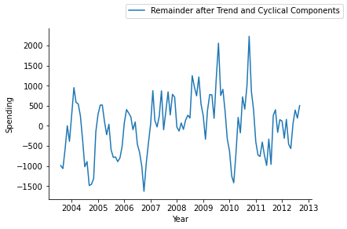

```python
fig,ax = plt.subplots()
ax.plot(dfCS['R2Public'],label='Remainder after Trend and Cyclical Components')
ax.set_xlabel('Year')
ax.set_ylabel('Spending')
ax.spines['right'].set_visible(False)
ax.spines['top'].set_visible(False)
fig.legend()
maxCorr = 0.0
period = np.NaN
for i in range(1,37):
    corr = dfCS['R2Public'].autocorr(lag=i)
    print('Correlation, lag ',i,'   ',corr)
    if corr > maxCorr:
        maxCorr = corr
        period = i
print('period = ',period,'     Maximum Correlation = ',maxCorr)
```

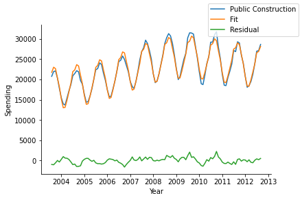

```python
fig,ax = plt.subplots()
ax.plot(dfCS['Public Construction'],label='Public Construction')
ax.plot(dfCS['fit'],label='Fit')
ax.plot(dfCS['R2Public'],label='Residual')
ax.set_xlabel('Year')
ax.set_ylabel('Spending')
ax.spines['right'].set_visible(False)
ax.spines['top'].set_visible(False)
fig.legend()
```